# U6614 : Final Project Presentation (Fall 2023)

2023-12-06

## Tackling the world’s lowest fertility rate

### Effect of childcare subsidies on birth-rate in South Korea.

## Research Question and Motivation

- How do family subsidies affect the availability of childcare facilities in different localities in South Korea? Ultimately, how has this policy impacted birth rate in the country?
- Why is this important?
  - This research can provide evidence-based policy recommendations for improving the accessibility and quality of childcare services in South Korea, which is facing a low fertility rate, a high demand for childcare, and challenges for working parents.
  - This can also contribute to the literature on the effects of government subsidies on childcare support, which is limited and inconclusive, especially at the local district level.

## Policy Context

The South Korean government has established various policies to counter the low fertility rate since the mid-2000s, but it still has the lowest fertility rate among OECD member countries. This project aims to focus on the childcare subsidies announced in 2018 and its impact on birth rate across districts in the country. In essence, the Korean government took a supply-first approach to addressing low fertility - but this strategy has been called into question since Covid as birth rates have continued to plummet. Therefore, there are alternative demand-first policy approaches that prioritise initiatives like cash incentives direct to parents.

The Third Mid- to Long-Term Basic Childcare Plan (2018-2022) was announced by the South Korean government in December 2017. The plan has 4 primary goals, among which are - increase the use of public childcare facilities to 40% by 2022-23, recalculate standard childcare costs considering the childcare process, facility size/type, and region and introduction of a ‘standard childcare time’ system to ensure sufficient facility use and meet the childcare demands of parents.

Experts have emphasized the importance of ensuring the “publicity of childcare” and expanding national and public plans for it. This was highlighted in the Third Basic Plan survey of experts on mid- to long-term childcare development plans, organized by the Childcare Policy Institute.The public, on the other hand, emphasized “securing trust and transparency of daycare centers”.

## Data Description

-Our main data source for government expenditure is from the Ministry of South Korea’s Local Finance Integrated Open System. We were able to source budget allocated to “Childcare & Family & Women” under the “Social Welfare” category for the years 2016-2022. Found here: https://www.lofin365. go.kr/eng

-We also used the repository from the Korea Childcare Promotion Institute (KCPI) under the Ministry of Health and Welfare to gather data on the number of public and private childcare center facilities and their enrollment capacities in the country over the same time period. Found here: https://www.kcpi.or.kr/kcpi/cyberpr/childcarestat1.do

-Finally, we used the official record of aggregated live births in the country to track the impact of the policy change, using national census data from Statistics Korea. Found here: https://kosis.kr/eng/#

We are focusing on district level data across all metrics, looking at time variation across a 7 year horizon (2016-2022). The 229 districts are aggregated across 17 provinces in the country.

## Variables Description

Our treatment/policy shock entails South Korea’s national strategy to strengthen the public nature of childcare in 2018. The goal of expanding the uptake of national and public daycare centers to 40% was planned to be achieved by easing local governments’ financial burden, raising the unit price of support when building these daycare centers, and supporting labor costs for local governments’ self-installed facilities.

- The dependent variable would be the national crude birth rate (births per 1,000 people per year)
- The independent variables would be:
  - Change in family welfare budget
  - And change in enrollment in public childcare facilities.
- The control variables are average household income and number of newly wed couples by province, and weighting by population in some variables

## Main Dependent Variable: Birth-rates

A declining birth-rate can be seen across all provinces. This nation-wide trend leads to Korea having the **lowest birth-rate in the world.**

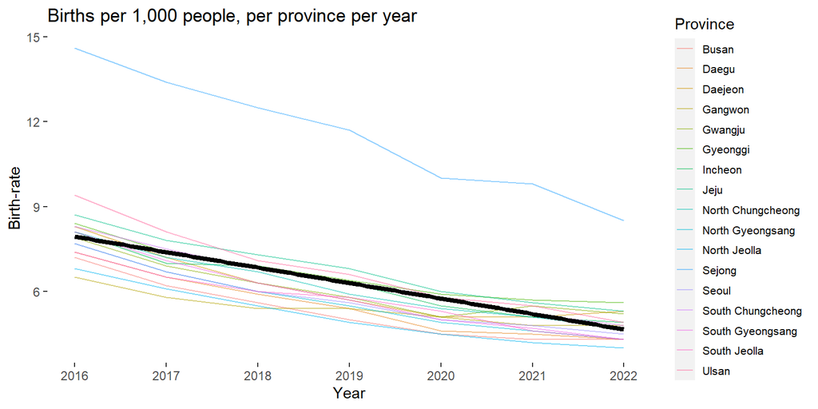

The top line, Sejong, is the capital province where the administrative functions of the government are and this is home to a higher proportion of young couples.

## Explanatory Variables (1/2) - Budget

We see that the budget allocated to childcare facilities has increased since after the plan was implemented. However, the allocation is starkly varying between capital (Seoul, Incheon, Gyeonggi) and non-capital regions (rest of the provinces)

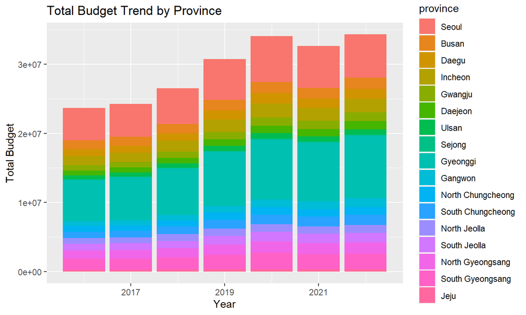

## Explanatory Variables (1/2) - Budget

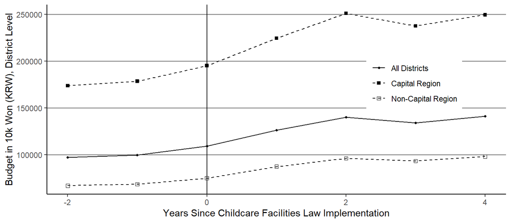

- Here, we are using panel data - repeated observations of district level budget, from 2016 to 2022 for our analysis. The plot shows an increase in the share of budget for childcare facilities for both groups after the policy came into effect in 2018. - While there is a clear difference in the budget share between capital and non-capital provinces before policy implementation, the year-over-year change appears to be about the same. In other words, the trends before the policy was implemented are parallel. When treatment occurs, the capital region provinces experience a larger increase in childcare budget compared to non-capital region provinces.

## Explanatory Variables (2/2) - Childcare Enrolment

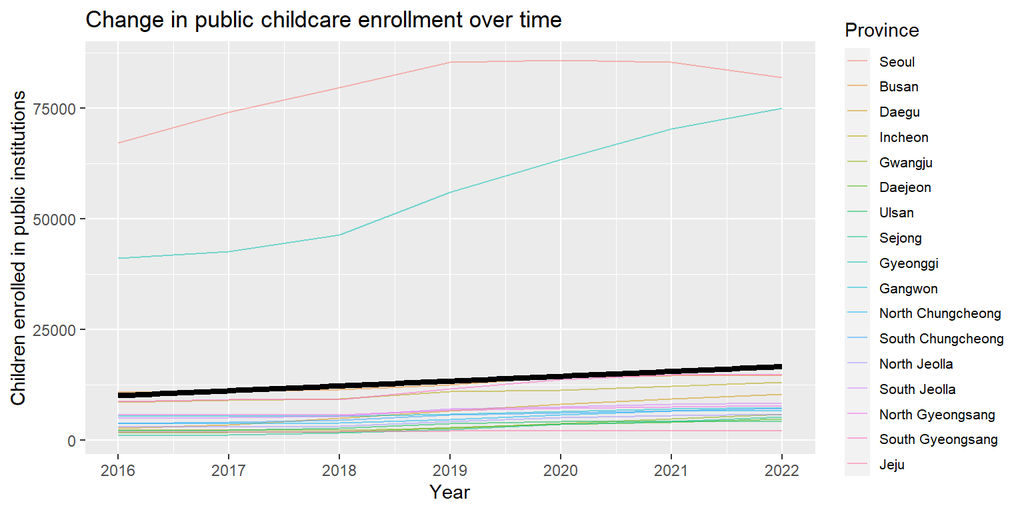

Seoul and Gyeonggi are the capital provinces, which received a higher amount of funding for their higher share of population and thus the crude enrollment has increased.

## Empirical Strategy (1/2)

Here is the PRF for our two way fixed effects models with province and year fixed effects:

To estimate the relationship between government childcare support budget and total enrollment in public childcare facilities, we use the following fixed effects regression equation: \[Y_{it} = \beta_0 + \beta_1 X_{it} + \beta_2 Z_{it} + \beta_3 W_{it} + \gamma_i + \mu_t + \varepsilon_{it}\]

where \(Y_{it}\) is the total enrollment in public childcare facilities in province \(i\) and year \(t\), \(X_{it}\) is the change in government childcare support budget, \(Z_{it}\) is the number of newly wed couples, \(W_{it}\) is the average household income at province level, and \(\varepsilon_{it}\) is the error term. The subscript i denotes the province and the subscript \(t\) denotes the year. The fixed effects \(\gamma_i\) controls for time invariant unobserved heterogeneity across provinces. The fixed effects \(\mu_t\) controls for province invariant unobserved heterogeneity across time.

## Empirical Strategy (2/2)

To estimate the relationship between total enrollment in public childcare facilities and Korea’s fertility rate, we use the following fixed effects regression equation: \[Y_{it} = \beta_0 + \beta_1 X_{it} + \beta_2 Z_{it} + \beta_3 W_{it} + \phi_i + \kappa_t + \varepsilon_{it}\]

where \(Y_it\) is South Korea’s birth rate in province \(i\) and year \(t\), \(X_it\) is the total enrollment in public childcare facilities, \(Z_it\) is the number of newly wed couples, \(W_it\) is the average household income at provide level, and \(\varepsilon_it\) is the error term. The subscript \(i\) denotes the province and the subscript t denotes the year. The fixed effects \(\phi_i\) control for unobserved heterogeneity across provinces. The fixed effects \(\kappa_t\) controls for province invariant unobserved heterogeneity across time.

## Regressions/TWFE analysis (1/2)

Effect of Family Budget on Public Childcare Facility Enrollment

|  | FE 1 | FE 2 | FE 3 | FE 4 |
| --- | --- | --- | --- | --- |
| Family Budget | 0.010*** | 0.007*** | 0.015*** | 0.008*** |
|  | (0.000) | (0.000) | (0.003) | (0.001) |
| N of Newly Married Couples |  | −0.129*** | −0.198** | −0.100** |
|  |  | (0.042) | (0.058) | (0.035) |
| Average Household Income |  | −0.098 | 18.164*** | 1.157 |
|  |  | (1.216) | (1.465) | (1.294) |
| N | 102 | 101 | 101 | 101 |
| R^2 | 1.00 | 1.00 | 0.85 | 1.00 |
| Adj. R^2 | 0.99 | 1.00 | 0.83 | 1.00 |
| Province FEs | X | X |  | X |
| Year FEs |  |  | X | X |

* p < 0.1, ** p < 0.05, *** p < 0.01  
Robust standard errors clustered by province are shown in parentheses. Observations are weighted by the population in each province.

## Regressions/TWFE analysis (2/2)

Effect of Public Childcare Facility Enrollment on Birth Rate

|  | FE 1 | FE 2 | FE 3 | FE 4 | FE 5 |
| --- | --- | --- | --- | --- | --- |
| N of Children Enrolled in Public Chidcare Facilities | 0.000*** | 0.000 | 0.000*** | 0.000* | 0.000* |
|  | (0.000) | (0.000) | (0.000) | (0.000) | (0.000) |
| N of Newly Married Couples |  | 0.000* | 0.000** | 0.000 |  |
|  |  | (0.000) | (0.000) | (0.000) |  |
| Average Household Income |  | −0.002*** | 0.001*** | 0.000 |  |
|  |  | (0.000) | (0.000) | (0.000) |  |
| N | 102 | 101 | 101 | 101 | 1595 |
| R^2 | 0.62 | 0.83 | 0.86 | 0.98 | 0.90 |
| Adj. R^2 | 0.54 | 0.79 | 0.85 | 0.98 | 0.89 |
| Province FEs | X | X |  | X |  |
| Year FEs |  |  | X | X | X |
| District FEs |  |  |  |  | X |

* p < 0.1, ** p < 0.05, *** p < 0.01  
Robust standard errors clustered by province are shown in parentheses. Observations are weighted by the population in each province.

## Findings and Conclusions

- We see that the crude birth rate has been declining across provinces, throughout our analysis period
- We also note that after the 2018 policy implementation, the budget allocated across provinces increases but the distribution is disproportionate in favour capital-region (Seoul, Incheon and Gyeonggi)
- Our regression results show high adjusted R^2 values which denote a good fit for our chosen models
- The coefficients are statistically significant at 1% for budget to enrollment regression and at varying levels for the enrollment to birth rate analysis

Thus we see that this policy did not achieve its stated objectives. The birth rate has continued to plummet and thus the South Korean government switched to a demand side approach in their Fourth Basic Plan (2023-2027) focusing on cash transfers and tax credits.

## Limitations and Next Steps

- All data in Korean, some nuances might be lost in translation
- Changes in district/province specification (Ex: one district was absorbed into another during our study) at administrative level can affect our findings and policy outcomes
- Annual aggregate data is slow to be updated on government portal and might be prone to measurement error
- Threats to internal validity include:
  - the budget is not solely for childcare facilities, it is also allocated to women and family healthcare (we account for this by considering enrollment data),
  - there might be other factors impacting the childcare centres’ enrollment (such as increased disposable income, reduced time for new parents to focus on children etc),
  - the government might allocate more funds to regions with lower fertility rates or fewer childcare facilities (reverse causality),
  - the cultural or religious norms of each district might influence both the birth rate and childcare uptake.

## Thank You!

- Manisha Swain (ms6549)
- Sharif Kazemi (ms6578)
- Shawn Lee (sl5191)